# ANLT222_HW1

Xi Liang

2/22/2017

In this problem, you will implement a Distance-Weighted Nearest Neighbor Classifier and run it on a 2-dimensional dataset. (You can’t use built-in knn functions in R to do this problem). You have to experiment with different distance measures and observe their influence on the classification performance. The training data has two classes as shown in figure 1. The training set along with test points and their correct label are saved in knnData.csv. Apply 3-NN and report your accuracy rate on test points for the following distance measures:

1. $L_2$ norm
2. $L_1$ norm
3. $L_/infinity$ norm

```r
setwd("~/Google Drive/UOP/Spring 2017/Machine Learning I/HW1")
```

```r
library(gmodels)
library(ggplot2)
library(flexclust)
```

```r
data <- read.csv('knnData.csv')
str(data)
```

```
## 'data.frame':    40 obs. of  6 variables:
##  $ trainPoints_x1: num  1.947 0.795 -0.265 -1.555 -0.956 ...
##  $ trainPoints_x2: num  4.257 3.557 2.128 0.408 -0.991 ...
##  $ trainLabel    : int  -1 -1 -1 -1 -1 -1 -1 -1 -1 -1 ...
##  $ testPoints_x1 : num  -1.889 4.234 -0.698 -3.152 4.049 ...
##  $ testPoints_x2 : num  -4.62 3.85 4.13 2.96 -4.01 ...
##  $ testLabel     : int  1 1 -1 -1 1 1 -1 -1 -1 -1 ...
```

```r
#splitingg the data into trainning set and testing set
train <- data[,1:2]
test <- data[, 4:5]

# seperate trainning and testing labels from the data set
train_label <- data[,3]
test_label <- data[,6]
```

Here, we try to get a general idea how our data points distributed among the plot.

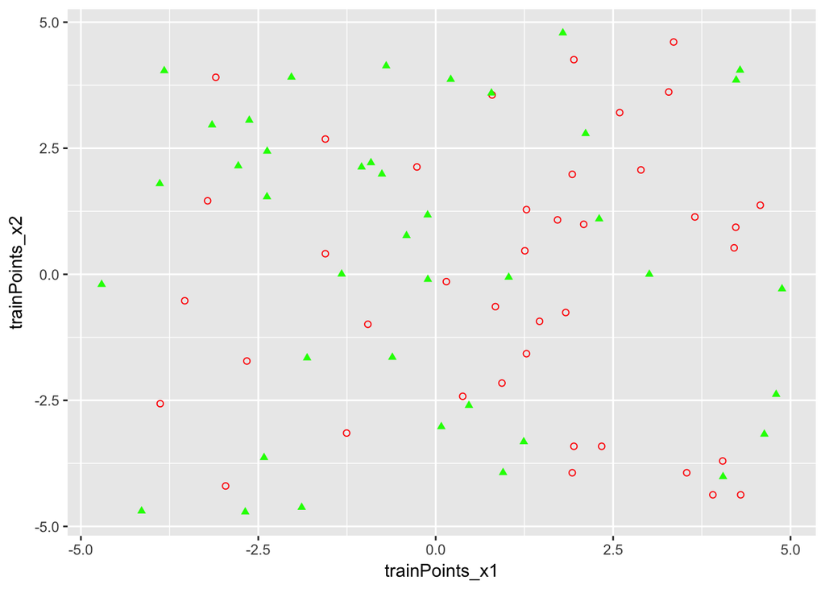

```r
tmp1 <- ggplot(train, aes(trainPoints_x1, trainPoints_x2)) +
  geom_point(pch= 21, colour = 'red') +
  geom_point(data = test, aes(testPoints_x1, testPoints_x2), pch=17, colour = 'green')

tmp1
```

We would use `dist2` function from the `flexclust` library to calculate the distance between the train and test data sets, based on Euclidean, Manhanttan, and maxium distances

```r
dist_EU <- dist2(train, test, method = "euclidean")
dist_Man <- dist2(train, test, method = "manhattan")
dist_Max <- dist2(train, test, method = "max")
```

We would create a function that would return the prediction based on the input distances

```r
KNN3_pred <- function(x) {
  #return the positions of the 3 closest data points to each of the test point
  KNN3_order <-apply(x, 2, order)
  KNN3_order <- head(KNN3_order, 3)

  #return the value of the 3 closest data points to each of the test point
  KNN3_value <- apply(x, 2, sort)
  KNN3_value <- head(KNN3_value, 3)

  #calculate the weight using 1/d^2
  KNN3_weight <-apply(KNN3_value, 2, FUN = function(x) {(1/x)^2} )
  #return the labels of the trainning set(closest 3), in matrix form
  KNN3_label <- matrix(train_label[c(KNN3_order)], ncol = 40)

  #multiply the weight with the label
  tmp1 <- KNN3_weight * KNN3_label
  #sum up the labels by columns
  tmp2 <- apply(tmp1, 2, sum)

  #if the sum is larger than 0, label it as 1, if the sum is negative, label it as -1
  pred <- ifelse(tmp2 >0, 1, -1)

  #return the prediction
  return(pred)
}
```

```r
distEU_pred <- KNN3_pred(dist_EU)
distMan_pred <- KNN3_pred(dist_Man)
distMax_pred <- KNN3_pred(dist_Max)
```

```r
CrossTable(x = test_label, distEU_pred, prop.chisq = FALSE)
```

```
##
##
##    Cell Contents
## |-------------------------|
## |                       N |
## |           N / Row Total |
## |           N / Col Total |
## |         N / Table Total |
## |-------------------------|
##
##
## Total Observations in Table:  40
##
##
##              | distEU_pred
##   test_label |        -1 |         1 | Row Total |
## -------------|-----------|-----------|-----------|
##           -1 |        23 |         3 |        26 |
##              |     0.885 |     0.115 |     0.650 |
##              |     0.852 |     0.231 |           |
##              |     0.575 |     0.075 |           |
## -------------|-----------|-----------|-----------|
##            1 |         4 |        10 |        14 |
##              |     0.286 |     0.714 |     0.350 |
##              |     0.148 |     0.769 |           |
##              |     0.100 |     0.250 |           |
## -------------|-----------|-----------|-----------|
## Column Total |        27 |        13 |        40 |
##              |     0.675 |     0.325 |           |
## -------------|-----------|-----------|-----------|
##
##
```

Using the Euclidean distance, we have 10 true postives and 23 true negatives, the correctness of the model is (23+10)/40 = 82.5%

```r
CrossTable(x = test_label, distMan_pred, prop.chisq = FALSE)
```

```
##
##
##    Cell Contents
## |-------------------------|
## |                       N |
## |           N / Row Total |
## |           N / Col Total |
## |         N / Table Total |
## |-------------------------|
##
##
## Total Observations in Table:  40
##
##
##              | distMan_pred
##   test_label |        -1 |         1 | Row Total |
## -------------|-----------|-----------|-----------|
##           -1 |        24 |         2 |        26 |
##              |     0.923 |     0.077 |     0.650 |
##              |     0.889 |     0.154 |           |
##              |     0.600 |     0.050 |           |
## -------------|-----------|-----------|-----------|
##            1 |         3 |        11 |        14 |
##              |     0.214 |     0.786 |     0.350 |
##              |     0.111 |     0.846 |           |
##              |     0.075 |     0.275 |           |
## -------------|-----------|-----------|-----------|
## Column Total |        27 |        13 |        40 |
##              |     0.675 |     0.325 |           |
## -------------|-----------|-----------|-----------|
##
##
```

Using the Manhattan distance, we have 11 true postives and 24 true negatives, the correctness of the model is (24+11)/40 = 87.5%

```r
CrossTable(x = test_label, distMax_pred, prop.chisq = FALSE)
```

```
##
##
##    Cell Contents
## |-------------------------|
## |                       N |
## |           N / Row Total |
## |           N / Col Total |
## |         N / Table Total |
## |-------------------------|
##
##
## Total Observations in Table:  40
##
##
##              | distMax_pred
##   test_label |        -1 |         1 | Row Total |
## -------------|-----------|-----------|-----------|
##           -1 |        24 |         2 |        26 |
##              |     0.923 |     0.077 |     0.650 |
##              |     0.889 |     0.154 |           |
##              |     0.600 |     0.050 |           |
## -------------|-----------|-----------|-----------|
##            1 |         3 |        11 |        14 |
##              |     0.214 |     0.786 |     0.350 |
##              |     0.111 |     0.846 |           |
##              |     0.075 |     0.275 |           |
## -------------|-----------|-----------|-----------|
## Column Total |        27 |        13 |        40 |
##              |     0.675 |     0.325 |           |
## -------------|-----------|-----------|-----------|
##
##
```

Using the Max distance, we have 11 true postives and 24 true negatives, the correctness of the model is (24+11)/40 = 87.5%